# GARCH

TanQingyue

2020/3/29

## 1.前期准备

## 1.1安装FinTS 程序包

$ wget http://labfile.oss.aliyuncs.com/courses/900/FinTS_0.4-5.tar.gz

## 1.2安装R 包

tseries、FinTS、timeDate、timeSeries、fBasics、fGarch

## 2.实验过程

## 2.1计算对数收益率

对上海证券综合指数日收盘价格取对数差分计算对数收益率。

```r
data<-read.csv("D:\\2345Downloads\\2000-2017.csv")
##计算对数收益率
close<-data[,2]          # 上证指数日收盘价
n<-length(close)         # 获取数据的长度
return<-log(close[2:n])-log(close[1:n-1])    # 上证指数的对数收益率
head(return)             #查看 return 的前6行数据
```

```
## [1]  0.002351519  0.037768650  0.035340827  0.018622775 -0.043202296
## [6] -0.028626936
```

```r
##也可以直接使用 diff 函数直接做差分求对数收益率
return<-diff(log(close))
head(return)
```

```
## [1]  0.002351519  0.037768650  0.035340827  0.018622775 -0.043202296
## [6] -0.028626936
```

## 2.2股票指数的可视化

在绘制图形之前，我们需要先将数据转化为时间序列格式，需要用到ts函数（用法：ts(数据向量，start=c(第一个数据所表示的年，月)，frequency=表示将时间分开的时间间隔)

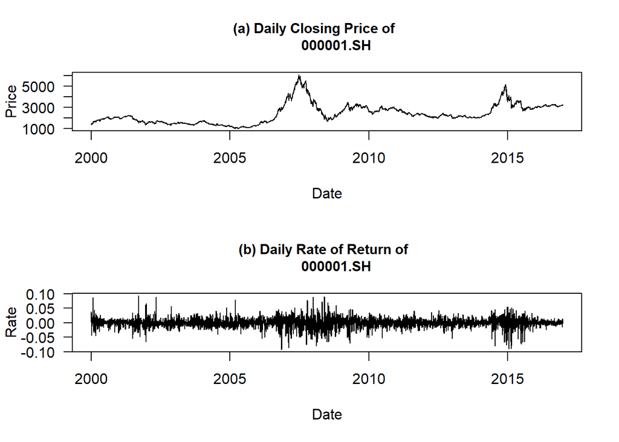

```r
Close.ts<-ts(close,start=c(2000),freq=250)
Return.ts<-ts(return,start=c(2000),freq=250)
par(mfrow=c(2,1))          #建立一个以两行一列排列图形的图形窗口
plot(Close.ts,type="l",main="(a) Daily Closing Price of
     000001.SH",xlab="Date", ylab="Price", cex.main=0.95,las=1)
plot(Return.ts,type="l",main="(b) Daily Rate of Return of
     000001.SH",xlab="Date", ylab="Rate", cex.main=0.95, las=1)
```

图(a)就是上海证券综合指数的日收盘价，图（b）是日收益率的时序图。从图形分析结果来看，2008 年和 2015 年两个时间段有明显的波动聚集现象。

## 2.3股票收益率的基本统计量

首先求解数据的基本统计量

```r
library(tseries)
u<-sum(return)/n                  # 求均值
e<-sqrt(sum((return-u)^2)/(n-1))  # 求标准差
s<-sum((return-u)^3)/((n-1)*e^3)  # 求偏度
k<-sum((return-u)^4)/((n-1)*e^4)  # 求峰度
jarque.bera.test(return)         # JB正态性检验
```

```
##
##  Jarque Bera Test
##
## data:  return
## X-squared = 3958.7, df = 2, p-value < 2.2e-16
```

## 2.4ACF 图和 PACF 图

用自相关函数（ACF）和偏自相关函数（PACF）来对收益率序列的自相关性进行分析。

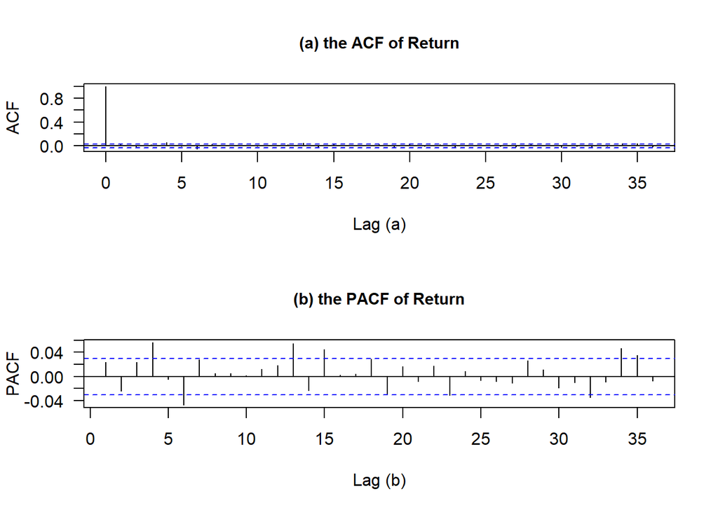

```r
par(mfrow=c(2,1))
acf(return,main='',xlab='Lag (a)',ylab='ACF',las=1) #画自相关图
title(main='(a) the ACF of Return',cex.main=0.95)  #为图形加标题，并设置标题大小
pacf(return,main='',xlab='Lag (b)',ylab='PACF',las=1) #画偏自相关图
title(main='(b) the PACF of Return',cex.main=0.95)
```

由 ACF 图和 PACF 图可以得出：两个图大部分函数值在置信区间内（图中蓝色虚线区域）上下跳跃,所以收益率序列自相关性很低,或者说具有很弱的自相关性，因此在条件期望模型中不需要引入自相关性部分，满足GARCH模型中的均值方程，收益率由一个常数项加上一个随机扰动项组成。

要拟合 GARCH 模型，我们还需要考察收益率平方的自相关性

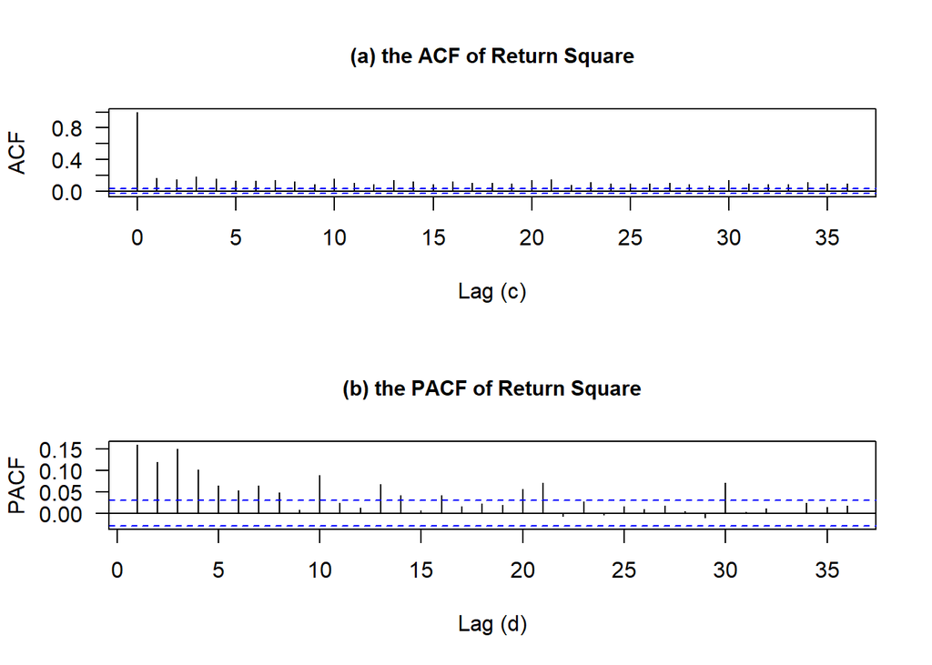

```r
par(mfrow=c(2,1))
return.square<-return^2
acf(return.square,main='',xlab='Lag (c)',ylab='ACF',las=1)
title(main='(a) the ACF of Return Square',cex.main=0.95)
pacf(return.square,main='',xlab='Lag (d)',ylab='PACF',las=1)
title(main='(b) the PACF of Return Square',cex.main=0.95)
```

尽管股价收益率序列的 ACF 值揭示了其弱相关性,但收益率平方的ACF值却表现出了一定的相关性和持续性，其大部分值都超过了置信区间（图中蓝色虚线）。注意到收益率平方的ACF值在滞后3、10、21、30期后都有缓慢衰退,说明了方差序列具有一定程度的序列相关性,因此采用 GARCH 模型来描述股价波动过程中的条件方差。

## 2.5ARCH 效应的检验

收益率的时序图表明，在日收益率数据中可能存在ARCH效应，如果存在ARCH效应，则可以进行GARCH模型的拟合。反之，不能用 GARCH 模型拟合方程。

```r
##ARCH 效应的检验，可以用FinTS包中的LM 检验
library(zoo)
library(FinTS)   #LM检验
ArchTest(return,lag=12)  #滞后 12 期
```

```
##
##  ARCH LM-test; Null hypothesis: no ARCH effects
##
## data:  return
## Chi-squared = 389.3, df = 12, p-value < 2.2e-16
```

检验的原假设是：不存在 ARCH 效应。检验结果为卡方统计量的值为389.3，对应的 P 值几乎为0，也就是说在 1% 的显著性水平上拒绝原假设，从而拒绝不存在 ARCH 效应的假设，收益率序列存在 ARCH 效应，可以进行 GARCH 模型的拟合。

## 2.6GARCH 模型的估计

```r
library(timeDate)
library(timeSeries)
library(fBasics)
library(fGarch)
m1<-garchFit(~1+garch(1,1),data=return,trace=F) #拟合GARCH（1,1）模型
m2<-garchFit(~1+garch(1,2),data=return,trace=F) #拟合GARCH（1,2）模型
m3<-garchFit(~1+garch(2,1),data=return,trace=F) #拟合GARCH（2,1）模型
m4<-garchFit(~1+garch(2,2),data=return,trace=F) #拟合GARCH（2,2）模型
summary(m1)  #显示模型的详细拟合结果
```

```
##
## Title:
##  GARCH Modelling
##
## Call:
##  garchFit(formula = ~1 + garch(1, 1), data = return, trace = F)
##
## Mean and Variance Equation:
##  data ~ 1 + garch(1, 1)
## <environment: 0x00000000192bde58>
##  [data = return]
##
## Conditional Distribution:
##  norm
##
## Coefficient(s):
##         mu       omega      alpha1       beta1
## 2.6199e-04  1.6676e-06  7.1982e-02  9.2407e-01
##
## Std. Errors:
##  based on Hessian
##
## Error Analysis:
##         Estimate  Std. Error  t value Pr(>|t|)
## mu     2.620e-04   1.826e-04    1.435    0.151
## omega  1.668e-06   4.096e-07    4.071 4.68e-05 ***
## alpha1 7.198e-02   6.948e-03   10.360  < 2e-16 ***
## beta1  9.241e-01   6.857e-03  134.759  < 2e-16 ***
## ---
## Signif. codes:  0 '***' 0.001 '**' 0.01 '*' 0.05 '.' 0.1 ' ' 1
##
## Log Likelihood:
##  12118.48    normalized:  2.852751
##
## Description:
##  Sun Mar 29 22:16:16 2020 by user: Administrator
##
##
## Standardised Residuals Tests:
##                                 Statistic p-Value
##  Jarque-Bera Test   R    Chi^2  990.7425  0
##  Shapiro-Wilk Test  R    W      0.9758627 0
##  Ljung-Box Test     R    Q(10)  36.51373  6.866768e-05
##  Ljung-Box Test     R    Q(15)  45.52293  6.32978e-05
##  Ljung-Box Test     R    Q(20)  53.6347   6.55187e-05
##  Ljung-Box Test     R^2  Q(10)  3.001381  0.9813915
##  Ljung-Box Test     R^2  Q(15)  8.340001  0.9094294
##  Ljung-Box Test     R^2  Q(20)  11.97937  0.9167842
##  LM Arch Test       R    TR^2   4.240415  0.9786969
##
## Information Criterion Statistics:
##       AIC       BIC       SIC      HQIC
## -5.703618 -5.697635 -5.703620 -5.701503
```

```r
summary(m2)
```

```
##
## Title:
##  GARCH Modelling
##
## Call:
##  garchFit(formula = ~1 + garch(1, 2), data = return, trace = F)
##
## Mean and Variance Equation:
##  data ~ 1 + garch(1, 2)
## <environment: 0x000000001849c8e8>
##  [data = return]
##
## Conditional Distribution:
##  norm
##
## Coefficient(s):
##         mu       omega      alpha1       beta1       beta2
## 2.6213e-04  1.6720e-06  7.2058e-02  9.2396e-01  1.0000e-08
##
## Std. Errors:
##  based on Hessian
##
## Error Analysis:
##         Estimate  Std. Error  t value Pr(>|t|)
## mu     2.621e-04   1.828e-04    1.434 0.151551
## omega  1.672e-06   4.677e-07    3.575 0.000351 ***
## alpha1 7.206e-02   1.353e-02    5.325 1.01e-07 ***
## beta1  9.240e-01   1.969e-01    4.692 2.70e-06 ***
## beta2  1.000e-08   1.847e-01    0.000 1.000000
## ---
## Signif. codes:  0 '***' 0.001 '**' 0.01 '*' 0.05 '.' 0.1 ' ' 1
##
## Log Likelihood:
##  12118.88    normalized:  2.852843
##
## Description:
##  Sun Mar 29 22:16:16 2020 by user: Administrator
##
##
## Standardised Residuals Tests:
##                                 Statistic p-Value
##  Jarque-Bera Test   R    Chi^2  988.4542  0
##  Shapiro-Wilk Test  R    W      0.9758918 0
##  Ljung-Box Test     R    Q(10)  36.50941  6.878564e-05
##  Ljung-Box Test     R    Q(15)  45.52432  6.326558e-05
##  Ljung-Box Test     R    Q(20)  53.61493  6.596114e-05
##  Ljung-Box Test     R^2  Q(10)  2.993229  0.981583
##  Ljung-Box Test     R^2  Q(15)  8.386035  0.9073755
##  Ljung-Box Test     R^2  Q(20)  12.00055  0.916057
##  LM Arch Test       R    TR^2   4.238585  0.9787361
##
## Information Criterion Statistics:
##       AIC       BIC       SIC      HQIC
## -5.703332 -5.695853 -5.703335 -5.700689
```

```r
summary(m3)
```

```
##
## Title:
##  GARCH Modelling
##
## Call:
##  garchFit(formula = ~1 + garch(2, 1), data = return, trace = F)
##
## Mean and Variance Equation:
##  data ~ 1 + garch(2, 1)
## <environment: 0x000000001962b408>
##  [data = return]
##
## Conditional Distribution:
##  norm
##
## Coefficient(s):
##         mu       omega      alpha1      alpha2       beta1
## 2.7128e-04  1.7510e-06  5.9759e-02  1.4612e-02  9.2146e-01
##
## Std. Errors:
##  based on Hessian
##
## Error Analysis:
##         Estimate  Std. Error  t value Pr(>|t|)
## mu     2.713e-04   1.828e-04    1.484 0.137844
## omega  1.751e-06   4.370e-07    4.006 6.17e-05 ***
## alpha1 5.976e-02   1.692e-02    3.531 0.000413 ***
## alpha2 1.461e-02   1.856e-02    0.787 0.431031
## beta1  9.215e-01   7.758e-03  118.774  < 2e-16 ***
## ---
## Signif. codes:  0 '***' 0.001 '**' 0.01 '*' 0.05 '.' 0.1 ' ' 1
##
## Log Likelihood:
##  12119.17    normalized:  2.852913
##
## Description:
##  Sun Mar 29 22:16:17 2020 by user: Administrator
##
##
## Standardised Residuals Tests:
##                                 Statistic p-Value
##  Jarque-Bera Test   R    Chi^2  1005.964  0
##  Shapiro-Wilk Test  R    W      0.9757217 0
##  Ljung-Box Test     R    Q(10)  37.06228  5.520644e-05
##  Ljung-Box Test     R    Q(15)  46.11139  5.104441e-05
##  Ljung-Box Test     R    Q(20)  54.23127  5.345223e-05
##  Ljung-Box Test     R^2  Q(10)  2.360193  0.9927602
##  Ljung-Box Test     R^2  Q(15)  7.913223  0.9272145
##  Ljung-Box Test     R^2  Q(20)  11.52563  0.9314369
##  LM Arch Test       R    TR^2   3.631852  0.9892015
##
## Information Criterion Statistics:
##       AIC       BIC       SIC      HQIC
## -5.703471 -5.695992 -5.703474 -5.700828
```

## 2.7GARCH 模型的标准化残差分析

拟合完 GARCH 模型后我们对模型结果的残差进行分析。

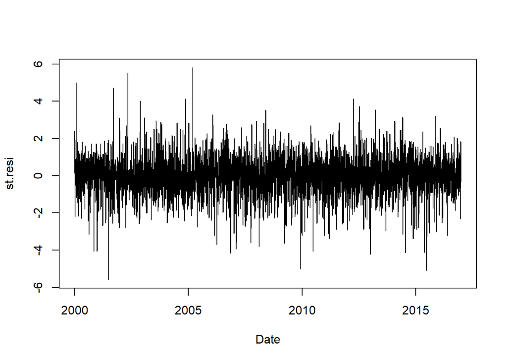

```r
resi<-residuals(m1,standardize=T)   #获得标准化残差
res<-ts(resi,frequency=250,start=c(2000))
plot(res,xlab='Date',ylab='st.resi',type='l')  #画出残差序列时序图
```

根据残差序列的时序图，可以看到残差序列没有明显的波动聚集效应

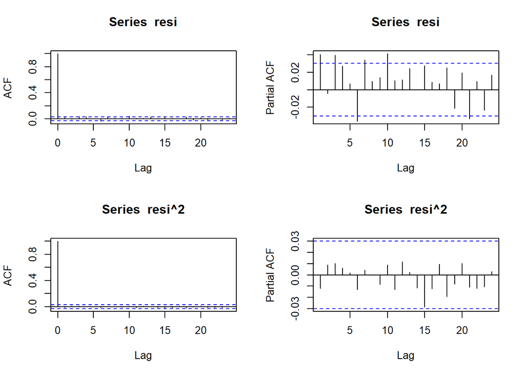

```r
par(mfcol=c(2,2))
acf(resi,lag=24)
acf(resi^2,lag=24)
pacf(resi,lag=24)
pacf(resi^2,lag=24)
```

上图是残差和残差平方的自相关图和偏自相关图。可以看到残差序列的ACF和PACF图大部分函数值在置信区间内（图中蓝色的虚线区域）上下跳跃,所以标准化残差序列并不具有自相关性，或者具有一定的弱相关性（PACF图结果）。而残差平方序列的 ACF 和 PACF 图都没有明显的拖尾或截尾现象,所有函数值都在置信区间内，因此其不具序列相关性。再将标准化冲击平方的ACF值与收益率平方的ACF值进行比较,结果表明 GARCH 模型可以有效地解释收益率序列。

对标准化残差平方用进行 Ljung-Box 方法进行检验

```r
Box.test(resi^2,lag=10,type='Ljung')  #残差平方的滞后10阶自相关检验
```

```
##
##  Box-Ljung test
##
## data:  resi^2
## X-squared = 3.0014, df = 10, p-value = 0.9814
```

```r
Box.test(resi^2,lag=15,type='Ljung')  #残差平方的滞后15阶自相关检验
```

```
##
##  Box-Ljung test
##
## data:  resi^2
## X-squared = 8.34, df = 15, p-value = 0.9094
```

```r
Box.test(resi^2,lag=20,type='Ljung')  #残差平方的滞后20阶自相关检验
```

```
##
##  Box-Ljung test
##
## data:  resi^2
## X-squared = 11.979, df = 20, p-value = 0.9168
```